# Collegiate Sports Budgets

Dor Avrahami - 207002478 and Noa Shalom - 208740597

10/06/2022

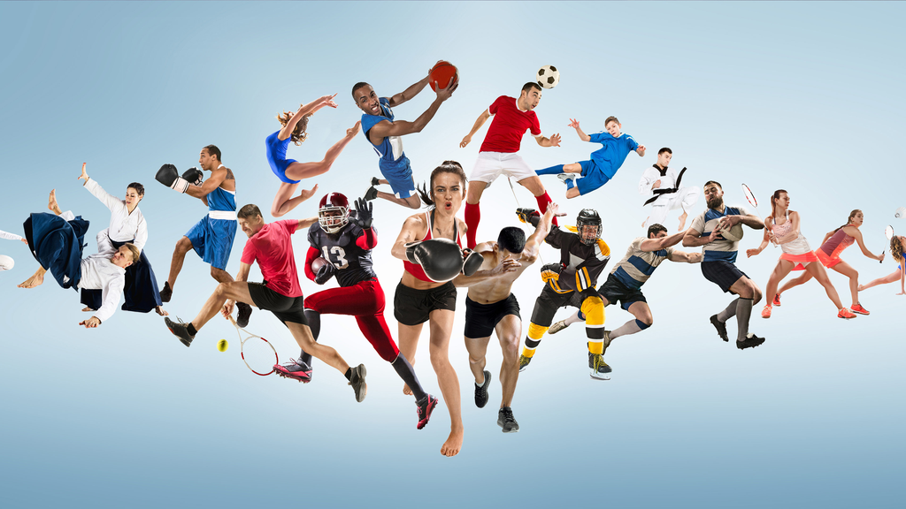

# Introduction

In this markdown, we analyze data of collegiate Sports Budgets.

[Click here to watch the data](https://github.com/rfordatascience/tidytuesday/blob/master/data/2022/2022-03-29/readme.md)

## Goals

Our research will focus on two main questions:

- Is there a correlation between the amount invested in the sports branches and the revenue they achieved?
- Is there a difference between the investments per individual in public and private collages?

# Data import

The data set is taken from Tidytuesday and comes in a CSV file.

Let’s read this file with read.csv function that imports the data into R.

```r
sports <- readr::read_csv('https://raw.githubusercontent.com/rfordatascience/tidytuesday/master/data/2022/2022-03-29/sports.csv')
```

# Data Dictionary

| variable | class | description |
| --- | --- | --- |
| year | integer | year, which is year: year + 1, eg 2015 is 2015 to 2016 |
| unitid | double | School ID |
| institution_name | character | School name |
| city_txt | character | City name |
| state_cd | character | State abbreviation |
| zip_text | character | Zip of school |
| classification_code | double | Code for school classification |
| classification_name | character | School classification |
| classification_other | character | School classification other |
| ef_male_count | double | Total male student |
| ef_female_count | double | Total Female student |
| ef_total_count | double | Total student for binary male/female gender (sum of previous two cols) |
| sector_cd | double | Sector code |
| sector_name | character | Sector name |
| sportscode | double | Sport code |
| partic_men | double | Participation men |
| partic_women | double | Participation women |
| partic_coed_men | double | Participation as coed men |
| partic_coed_women | double | Participation for coed women |
| sum_partic_men | double | Sum of participation for men |
| sum_partic_women | double | Sum of participation women |
| rev_men | double | Revenue in USD for men |
| rev_women | double | Revenue in USD for women |
| total_rev_menwomen | double | Total revenue for both |
| exp_men | double | Expenditures in USD for men |
| exp_women | double | Expenditures in USD for women |
| total_exp_menwomen | double | Total Expenditure for both |
| sports | character | Sport name |

# Tidying

First, we will make some changes, by adding a column of the male and female participants combined.

Also, we will change the NA values to zeroes in certain columns that should contain numerical values only, so the data will be more capable to work with.

```r
sports<-sports%>%
  mutate(total_partic=partic_men+partic_women)

sports<-sports%>%
  relocate(total_partic, .after = sum_partic_women)

sports$total_partic[is.na(sports$total_partic)] <- 0
sports$partic_women[is.na(sports$partic_women)] <- 0
sports$partic_men[is.na(sports$partic_men)] <- 0
sports$rev_men[is.na(sports$rev_men)] <- 0
sports$rev_women[is.na(sports$rev_women)] <- 0
sports$exp_men[is.na(sports$exp_men)] <- 0
sports$exp_women[is.na(sports$exp_women)] <- 0
sports$total_rev_menwomen[is.na(sports$total_rev_menwomen)] <- 0
sports$total_exp_menwomen[is.na(sports$total_exp_menwomen)] <- 0
```

In our project, we will concentrate in the familiar classifications only, so we will get rid of the rows, where the classification name is “Other” or “Independent”.

```r
sports <- subset (sports, select = -c(classification_other,partic_coed_men,partic_coed_women))
sports<-sports[!(sports$classification_name=="Other"|sports$classification_name=="Independent"),]
```

Now we got it clean, let’s take a look at the tidy sports table:

```r
glimpse(sports)
```

```
## Rows: 128,612
## Columns: 26
## $ year                <dbl> 2015, 2015, 2015, 2015, 2015, 2015, 2015, 2015, 20~
## $ unitid              <dbl> 100654, 100654, 100654, 100654, 100654, 100654, 10~
## $ institution_name    <chr> "Alabama A & M University", "Alabama A & M Univers~
## $ city_txt            <chr> "Normal", "Normal", "Normal", "Normal", "Normal", ~
## $ state_cd            <chr> "AL", "AL", "AL", "AL", "AL", "AL", "AL", "AL", "A~
## $ zip_text            <chr> "35762", "35762", "35762", "35762", "35762", "3576~
## $ classification_code <dbl> 2, 2, 2, 2, 2, 2, 2, 2, 2, 2, 1, 1, 1, 1, 1, 1, 1,~
## $ classification_name <chr> "NCAA Division I-FCS", "NCAA Division I-FCS", "NCA~
## $ ef_male_count       <dbl> 1923, 1923, 1923, 1923, 1923, 1923, 1923, 1923, 19~
## $ ef_female_count     <dbl> 2300, 2300, 2300, 2300, 2300, 2300, 2300, 2300, 23~
## $ ef_total_count      <dbl> 4223, 4223, 4223, 4223, 4223, 4223, 4223, 4223, 42~
## $ sector_cd           <dbl> 1, 1, 1, 1, 1, 1, 1, 1, 1, 1, 1, 1, 1, 1, 1, 1, 1,~
## $ sector_name         <chr> "Public, 4-year or above", "Public, 4-year or abov~
## $ sportscode          <dbl> 1, 2, 3, 7, 8, 15, 16, 22, 26, 33, 1, 2, 3, 8, 12,~
## $ partic_men          <dbl> 31, 19, 61, 99, 9, 0, 0, 7, 0, 0, 32, 13, 0, 10, 0~
## $ partic_women        <dbl> 0, 16, 46, 0, 0, 21, 25, 10, 16, 9, 0, 20, 68, 7, ~
## $ sum_partic_men      <dbl> 31, 19, 61, 99, 9, 0, 0, 7, 0, 0, 32, 13, 0, 10, 2~
## $ sum_partic_women    <dbl> 0, 16, 46, 0, 0, 21, 25, 10, 16, 9, 0, 20, 68, 7, ~
## $ total_partic        <dbl> 0, 35, 107, 0, 0, 0, 0, 17, 0, 0, 0, 33, 0, 17, 0,~
## $ rev_men             <dbl> 345592, 1211095, 183333, 2808949, 78270, 0, 0, 782~
## $ rev_women           <dbl> 0, 748833, 315574, 0, 0, 410717, 298164, 131145, 3~
## $ total_rev_menwomen  <dbl> 345592, 1959928, 498907, 2808949, 78270, 410717, 2~
## $ exp_men             <dbl> 397818, 817868, 246949, 3059353, 83913, 0, 0, 9961~
## $ exp_women           <dbl> 0, 742460, 251184, 0, 0, 432648, 340259, 113886, 3~
## $ total_exp_menwomen  <dbl> 397818, 1560328, 498133, 3059353, 83913, 432648, 3~
## $ sports              <chr> "Baseball", "Basketball", "All Track Combined", "F~
```

# Visualizations

Let’s get started!

First, we will show the distribution of collages expenses over the years invested in sports:

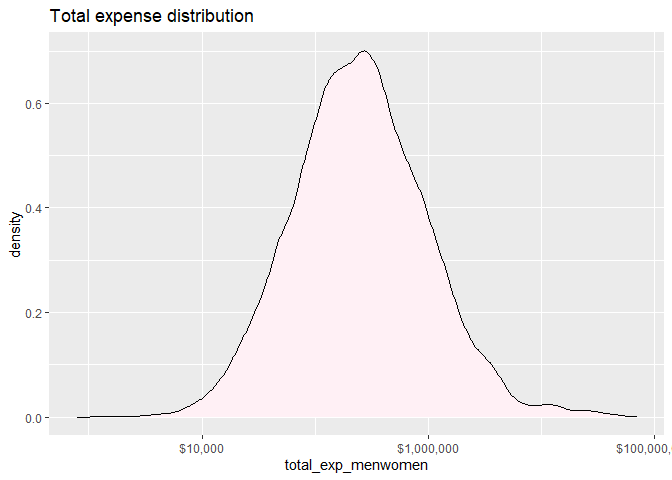

```r
total_expense_distribution<-ggplot(data=sports, aes(x=total_exp_menwomen))+
  geom_density(fill="lavenderblush")+
  scale_x_log10(labels = dollar_format(prefix = "$"))
total_expense_distribution+ggtitle("Total expense distribution")
```

As we can see, the amount of expenses on men and women combined distribute almost normally.

*EXPENSES OVER THE YEARS*

Next, we will show expenses on the variety of sports over the years:

```r
total_expense_by_year<-sports%>%
  group_by(year)%>%
  summarize(total_expense=sum(total_exp_menwomen))
```

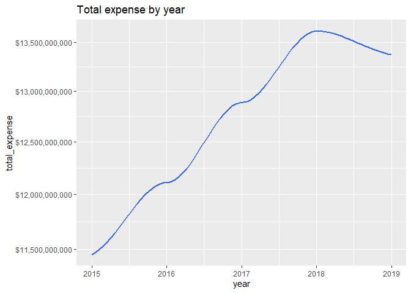

```r
total_expense_by_year<-ggplot(data = total_expense_by_year) +
  geom_smooth(mapping = aes(x = year, y = total_expense))+
  scale_y_log10(labels = dollar_format(prefix = "$"))
total_expense_by_year+ ggtitle("Total expense by year")
```

From the chart we can learn that the amount of investments raised between 2015 to 2018, and since 2018 slightly decreased (until 2019).

*TOP 5*

Now, let’s see on which sports branches collages invest the most!

```r
most_invested <- sports%>%
  group_by(sports)%>%
  summarize(sum(total_exp_menwomen))

most_invested<-most_invested[rev(order(most_invested[,2])),]%>%
pull(sports)
top_5<-most_invested[1:5]
top_5
```

```
## [1] "Football"           "Basketball"         "Soccer"
## [4] "Baseball"           "All Track Combined"
```

With those five sports branches, we will show the investment in those sports in women and men in separate.

```r
expense_by_gender<-sports%>%
  filter(sports %in% top_5)%>%
  select (sports,c(year,exp_men,exp_women,sports,total_exp_menwomen,total_partic))
```

```r
expense_on_top_5_sports_men<-ggplot(expense_by_gender,
aes(x =year, y =exp_men, fill = sports)) +
geom_col(position = position_dodge())+
  scale_y_log10(labels = dollar_format(prefix = "$")) +
  coord_cartesian(ylim=c(1000000,100000000))
```

```r
expense_on_top_5_sports_women<-ggplot(expense_by_gender,
aes(x =year, y =exp_women, fill = sports)) +
geom_col(position = position_dodge())+
  scale_y_log10(labels = dollar_format(prefix = "$")) +
  coord_cartesian(ylim=c(1000000,100000000))
```

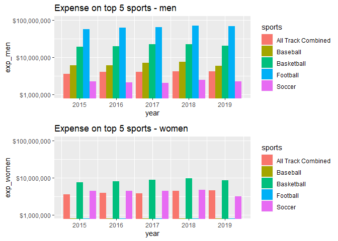

```r
grid.arrange(expense_on_top_5_sports_men+ggtitle("Expense on top 5 sports - men"),expense_on_top_5_sports_women+ggtitle("Expense on top 5 sports - women"))
```

As we can see, there are big differences in the amounts invested between men and women.

You can see it clearly in the amounts of money invested in each sport from the “top 5”, and also the fact that two of the five most invested sports are not in the women chart (which means all the money goes for the men, not fair…)

*NCAA*

NCAA - The National Collegiate Athletic Association is a member-led organization dedicated to the well-being and lifelong success of college athletes, and considered as the best league to take part in the USA.

We want to concentrate in the leagues divisions with football in the NCAA, and check the connection between the number of participants and the revenues by men and women.

```r
ncaa<-sports%>%
  select(classification_name,partic_men,rev_men,partic_women,rev_women)%>%
filter(classification_name==c("NCAA Division I-FBS","NCAA Division II with football","NCAA Division III with football"))
```

```r
leagues_men<-ggplot(ncaa, aes(x=partic_men, y=rev_men,colour=classification_name))+
scale_y_log10(labels = dollar_format(prefix = "$")) +
  geom_point()
```

```r
leagues_women<-ggplot(ncaa, aes(x=partic_women, y=rev_women,colour=classification_name))+
scale_y_log10(labels = dollar_format(prefix = "$")) +
  geom_point()
```

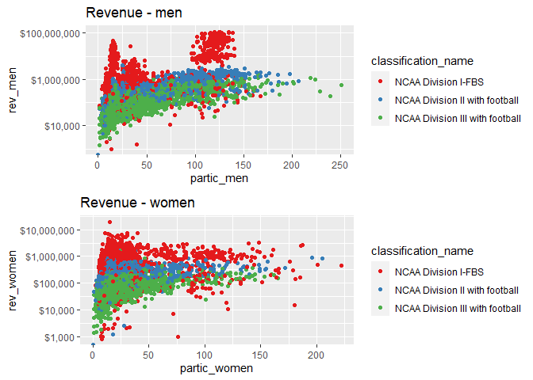

```r
grid.arrange(leagues_men+ggtitle("Revenue - men")+ scale_color_brewer(palette="Set1"),leagues_women+ggtitle("Revenue - women")+ scale_color_brewer(palette="Set1"))
```

There are a lot of conclusions we can learn from those charts:

- First, in NCAA division 1 the profits are highest, and as we go down by divisions level, the profits decrease.
- Second, the number of participants is not a factor to the revenues - what matter is the league itself.
- Third, in here we can see the differences between men and women - the profits of men are up to 100M dollars, and of women are up to 10M dollars (maybe because women are less invested as we have seen above…)

*PARTICIPANTS IN TOP 5 SPORTS*

Next, let’s check the median and various of participants number in every sports branch in top five most invested sports:

```r
pratic_num_by_sport<-sports%>%
  filter(sports %in% top_5)%>%
  mutate(number_of_partic=(sum_partic_men+sum_partic_women))%>%
  select(sports,number_of_partic)
```

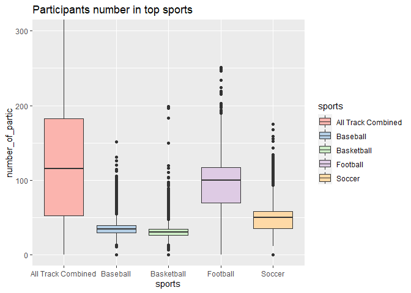

```r
participants<-pratic_num_by_sport %>%
  ggplot(aes(x = sports, y = number_of_partic,fill = sports))+
  geom_boxplot()+
  coord_cartesian(ylim=c(0,300))+
  scale_fill_brewer(palette = "Pastel1")
participants+ggtitle("Participants number in top sports")
```

As we can see, the various of participants number in All Track Combined is the biggest (by far..), and on the other hand, in Basketball for example, the number of participants is relatively permanent in the different collages.

Also, the box plot shows us that in top 5 sports, as the various of participants decreases , the median of number of participants decreases.

# Modeling

Let’s start with the interesting stuff!

## First-model

We will check if there is a correlation between the amount of expenses and revenues.

```r
exp_rev<-sports%>%
  group_by(sports)%>%
  summarize(tot_sum_revenue=sum(total_rev_menwomen),tot_sum_expenses=sum(total_exp_menwomen))%>%
  mutate(profit=tot_sum_revenue-tot_sum_expenses)
```

## Hypothesis

Our null hypothesis is that expense and revenue are not correlated - every sport branch has his own profit or losses and the general connection is not permanent .

```r
exp_rev_corr<-lm(formula =log1p(tot_sum_expenses)~log1p(tot_sum_revenue), data= exp_rev)
summary(exp_rev_corr)
```

```
##
## Call:
## lm(formula = log1p(tot_sum_expenses) ~ log1p(tot_sum_revenue),
##     data = exp_rev)
##
## Residuals:
##      Min       1Q   Median       3Q      Max
## -0.51710 -0.16869 -0.03351  0.08392  0.79162
##
## Coefficients:
##                        Estimate Std. Error t value Pr(>|t|)
## (Intercept)             0.28274    0.20230   1.398    0.171
## log1p(tot_sum_revenue)  0.99327    0.01067  93.099   <2e-16 ***
## ---
## Signif. codes:  0 '***' 0.001 '**' 0.01 '*' 0.05 '.' 0.1 ' ' 1
##
## Residual standard error: 0.2607 on 36 degrees of freedom
## Multiple R-squared:  0.9959, Adjusted R-squared:  0.9957
## F-statistic:  8667 on 1 and 36 DF,  p-value: < 2.2e-16
```

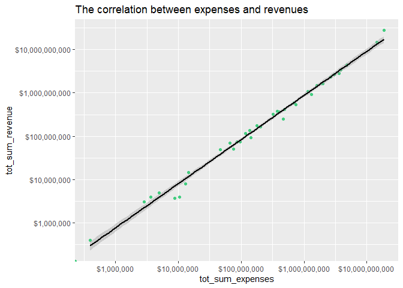

```r
regresion<-exp_rev%>%
ggplot(aes(y=tot_sum_revenue, x=tot_sum_expenses))+
  geom_point(color="seagreen3")+
  scale_y_log10(labels = dollar_format(prefix = "$"))+
  scale_x_log10(labels = dollar_format(prefix = "$"))+
  stat_smooth(method = "lm",color="black")
regresion+ggtitle("The correlation between expenses and revenues")
```

As we can see the p-value is significantly lower than 0.05, so in contrary to our expectation, there is a correlation between the expenses and the revenues .

The R squared is above 99 percents so the correlation is very strong, almost identical, although the information in exp_rev table shows us that there are some big differences - the connection between investments and revenues is changing in different sports branches.

Let’s take a look in exp_rev and see the differences by looking at profit column:

```r
print(exp_rev,n=25)
```

```
## # A tibble: 38 x 4
##    sports             tot_sum_revenue tot_sum_expenses     profit
##    <chr>                        <dbl>            <dbl>      <dbl>
##  1 All Track Combined      2840578413       3592928928 -752350515
##  2 Archery                    4956285          4952804       3481
##  3 Badminton                  3004075          2887973     116102
##  4 Baseball                3456842954       3833906615 -377063661
##  5 Basketball             14995135589      14277977052  717158537
##  6 Beach Volleyball          75248431         96887455  -21639024
##  7 Bowling                  136360335        137428098   -1067763
##  8 Diving                     3722366          8691148   -4968782
##  9 Equestrian                92062239        141705270  -49643031
## 10 Fencing                   50690828         74953117  -24262289
## 11 Field Hockey             415798460        489488447  -73689987
## 12 Football               27619070992      18586165236 9032905756
## 13 Golf                    1638244466       1927733053 -289488587
## 14 Gymnastics               249580814        470796989 -221216175
## 15 Ice Hockey              1092628924       1145674973  -53046049
## 16 Lacrosse                1491968997       1616085611 -124116614
## 17 Other Sports             115649680        117745664   -2095984
## 18 Rifle                      7954624         13139032   -5184408
## 19 Rodeo                     68660200         66729908    1930292
## 20 Rowing                   537460512        738333145 -200872633
## 21 Sailing                   14648696         14588990      59706
## 22 Skiing                    74766603         86321881  -11555278
## 23 Soccer                  4394928966       4846526850 -451597884
## 24 Softball                2289337182       2621158795 -331821613
## 25 Squash                    49501836         46410330    3091506
## # ... with 13 more rows
```

## Second model

Now we will move to our next question - is there a difference between the investment in public and private collages?

```r
sectors<-sports%>%
  filter(year==2015)%>%
  group_by(institution_name,sector_name)%>%
  summarise(tot_part_man=sum(sum_partic_men),tot_part_woman=sum(sum_partic_women)
  ,tot_exp=sum(total_exp_menwomen),sum_exp_men=sum(exp_men)
  ,sum_exp_women=sum(exp_women))%>%
  mutate(women_exp_mean=(sum_exp_women/tot_part_woman))%>%
  mutate(man_exp_mean=(sum_exp_men/tot_part_man))%>%
  mutate(exp_mean_by_person=tot_exp/(tot_part_woman+tot_part_man))%>%
  mutate(is_public=str_detect(sector_name,"Public"))
```

Let’s start from showing the distributions of public and private collages expense mean:

```r
public_exp<-sectors%>%
  filter(is_public)

public_exp$man_exp_mean[is.nan(public_exp$man_exp_mean)] <- 0
public_exp$women_exp_mean[is.nan(public_exp$women_exp_mean)] <- 0

public_exp_mean_by_person<-ggplot(data=public_exp, aes(x=exp_mean_by_person))+
  scale_x_log10(labels = dollar_format(prefix = "$"))+
  geom_density(fill="orange")+
  coord_cartesian(ylim=c(0,1))
```

```r
private_exp<-sectors%>%
  filter(!is_public)

private_exp$man_exp_mean[is.nan(private_exp$man_exp_mean)] <- 0
private_exp$women_exp_mean[is.nan(private_exp$women_exp_mean)] <- 0

private_exp_mean_by_person<-ggplot(data=private_exp, aes(x=exp_mean_by_person))+
  scale_x_log10(labels = dollar_format(prefix = "$"))+
  geom_density(fill="beige")
```

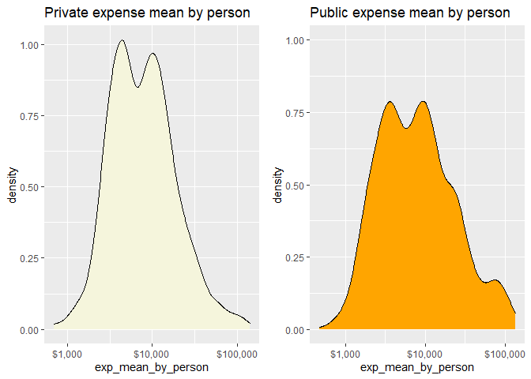

```r
grid.arrange(private_exp_mean_by_person+ggtitle("Private expense mean by person"),
             public_exp_mean_by_person+ggtitle("Public expense mean by person")
             ,ncol=2)
```

So, as we can see there are two “humps” is these distributions. A possible explanation is the difference of means for the women and men.

Let’s find the means and see if there are differences.

```r
private_women_exp_mean<-mean(private_exp$women_exp_mean)
private_men_exp_mean<-mean(private_exp$man_exp_mean)
```

```r
public_women_exp_mean<-mean(public_exp$women_exp_mean)
public_men_exp_mean<-mean(public_exp$man_exp_mean)
```

Private school expense on women mean:

```r
private_women_exp_mean
```

```
## [1] 11126.6
```

Private school expense on men mean:

```r
private_men_exp_mean
```

```
## [1] 12777.54
```

Public school expense on women mean:

```r
public_women_exp_mean
```

```
## [1] 12166.67
```

Public school expense on men mean:

```r
public_men_exp_mean
```

```
## [1] 17117.6
```

As we Assumed, there are differences between men and women means.

Next thing we are going to do is a T test to check if there is a difference between private and public collages investments per person:

```r
t.test(private_exp$exp_mean_by_person,public_exp$exp_mean_by_person)
```

```
##
##  Welch Two Sample t-test
##
## data:  private_exp$exp_mean_by_person and public_exp$exp_mean_by_person
## t = -3.3088, df = 1952.1, p-value = 0.000954
## alternative hypothesis: true difference in means is not equal to 0
## 95 percent confidence interval:
##  -4226.932 -1080.891
## sample estimates:
## mean of x mean of y
##  11938.17  14592.08
```

Our null hypothesis was that there isn’t a difference in the investments in public and private collages. As we can see in the t-test above, the p-value is 0.000954, so we can say in significance level of 0.05 that there is a difference, so we do reject the null hypothesis.

# Conclusions

We checked two main questions -

- Is there a correlation between the amount of total investments in the sport branches and the total revenues they achieved?
- Is there a difference between the investments per individual in public and private collages?

The first model showed a strong correlation between the two variables, even though the connection between investments and revenues is not permanent in every sport branch.

The second model reviled that there are differences in the investments in public and private collages, and surprisingly,participants in public collages are more invested!

Thank you for reading and have a great day!